# Introduction to Network Analysis

Python

network analysis

This notebook is an introduction to basic network analysis in Python.

Author

prAxIs UBC Team  
*Alex Ronczewski, Irene Berezin*

Published

13 October 2025

This notebook introduces key concepts in network analysis pertaining to sociology and provides a hands-on tutorial to using the NetworkX Python library.

## 1. What is Network analysis?

**Network Analysis** is a set of techniques used to study the structure and dynamics of networks. **Networks** are collections of objects/locations/entities (called *nodes*) connected by relationships (called *edges*). Network analysis has applications in many fields, including sociology, biology, economics, computer science, and more.

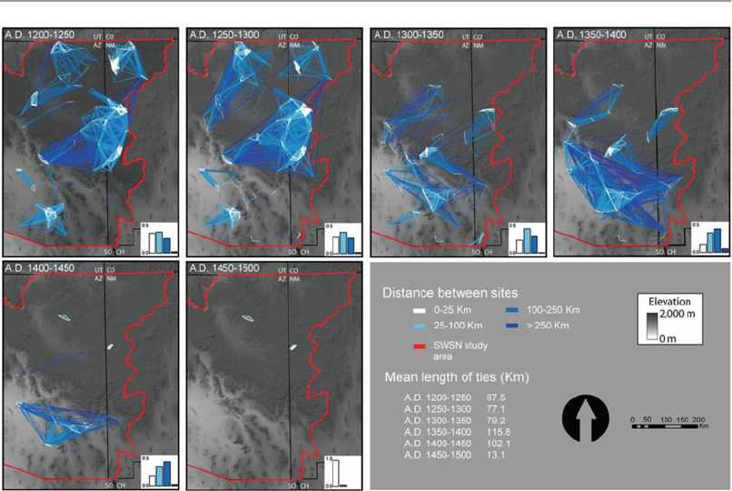

Regional networks of ceramic similarity across time in the greater Arizona/New Mexico area of the US (From Mills et al. 2013, Fig. 2)

**Network science in Sociology** Network analysis in sociology is the systematic study of social structure through the mapping and measurement of relationships among individuals, groups, or organizations. It is not a discipline on its own, but rather a methodological and theoretical approach within sociology that helps conceptualize, describe, and model society as interconnected sets of actors linked by specific relationships. Network analysis in sociology is a core tool for understanding how relationships and social structures impact individuals and groups.

### 1.1 Key terms

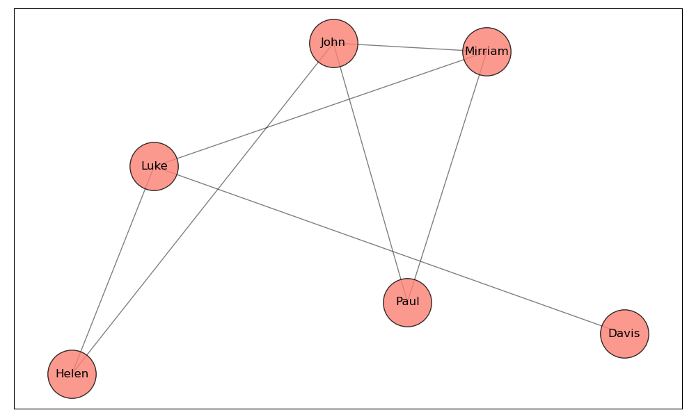

An example of a graph with nodes and edges.

**Node:** A node is a representation of an individual entity or actor in a network. In different contexts, nodes can be people, organizations, cities, or any other unit of analysis.

**Edge:** An edge represents the relationship or connection between two nodes. Edges can be directed (having a specific direction from one node to another) or undirected (no direction, implying a mutual relationship).

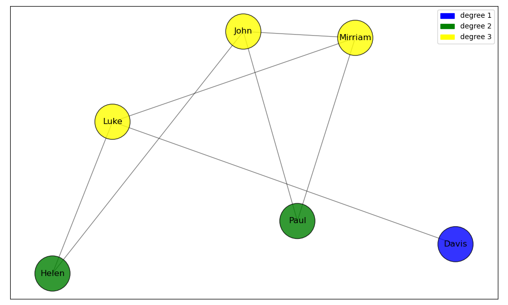

An example of a network with nodes colored by degree.

**Degree:** The degree of a node is the number of edges connected to it. In directed networks, this can be further divided into in-degree (number of incoming edges) and out-degree (number of outgoing edges).

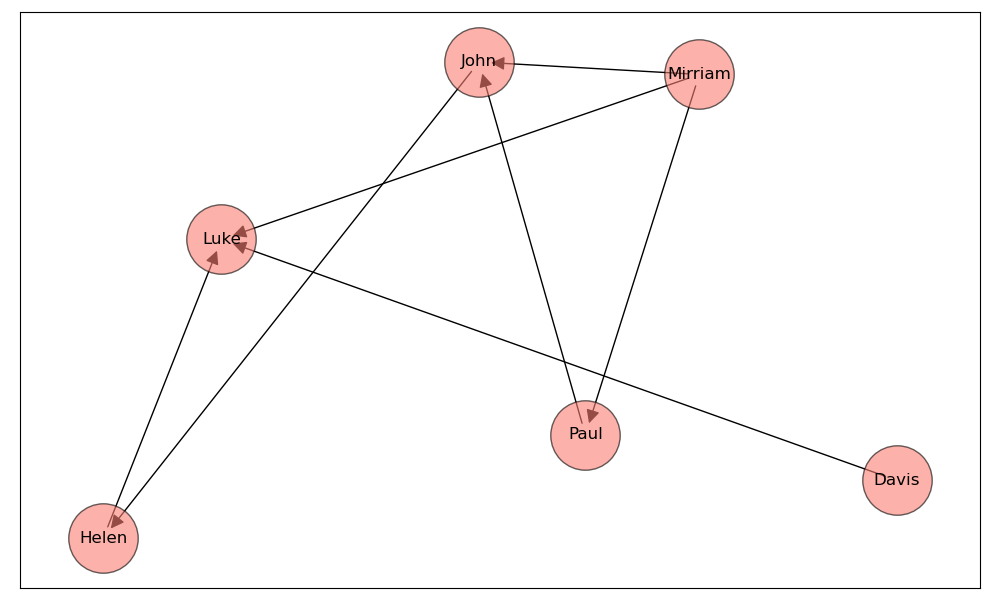

The network above is an example of a **Undirected graph**, a graph with no direction. This means that if there is a connection between node A and node B, it is bidirectional: A is connected to B, and B is connected to A.

The example to the left is a **directed graph**: the edges between nodes have a specific direction. This means that if there is an edge from node A to node B, it does not imply there is an edge from B to A unless explicitly stated.

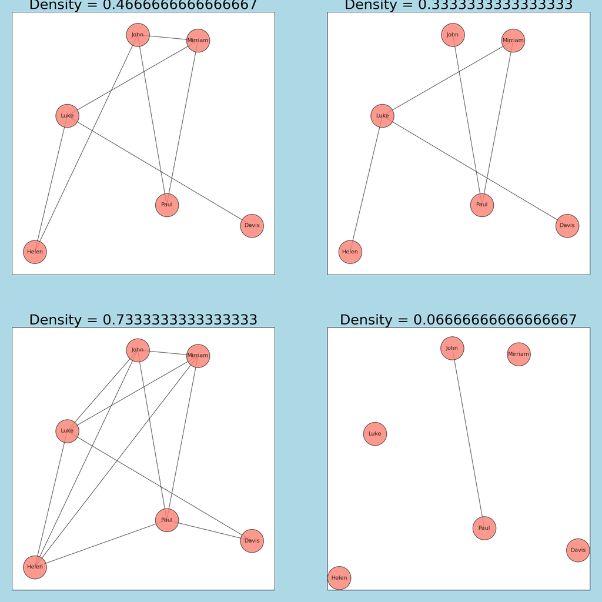

**Density:** Density is a measure that indicates how closely connected the nodes in a network are. Specifically, it refers to the ratio of the number of actual edges in the network to the maximum possible number of edges between nodes.

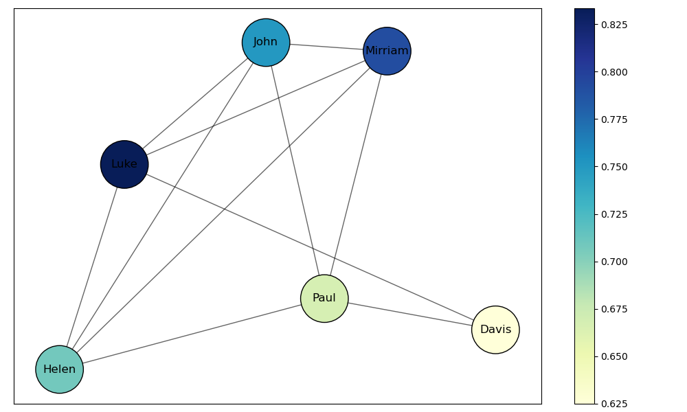

**Centrality:** Centrality measures the importance, influence, or prominence of nodes (entities) within a network. The centrality of a node tells us how “important” a node is to the aggregate network. There are many different kinds of centrality, but the four most well-known ones are degree, betweenness, closeness, and eigenvector centrality.

### 1.2 NetworkX

`NetworkX` is a Python library that is used for the creation, manipulation, and visualization of complex networks. It provides tools to work with both undirected and directed networks, perform network-related calculations, and visualize the results.

A library in Python is a collection of code that makes everyday tasks more efficient. In this case working with networks becomes much simpler when using NetworkX.

If you want to read the NetworkX documentation you can follow the [NetworkX documentation link](https://networkx.org/documentation/stable/reference/introduction.html). This link shows what kind of commands exist within the NetworkX library.

#### 1.2.1 Importing NetworkX

We can import NetworkX using the `import` command. At the same time, we’ll also import the `matplotlib.pyplot` library, for plotting graphs. Additionally, we’ll import `pandas` for basic data wrangling, and `numpy` for math. The `as` command allows us to use `networkx` commands without needing to type out `networkx` each time. Along with some other libraries.

```python
import matplotlib.pyplot as plt #allows us to call the matplotlib.pyplot library as 'plt'
import matplotlib.patches as mpatches #imports mpatches matplotlib subpackage
import networkx as nx #allows us to call the networkx library as 'nx'
import pandas as pd #allows us to call the pandas library as 'pd'
import numpy as np
import geopandas as gpd
import contextily as ctx
from mpl_toolkits.axes_grid1.inset_locator import inset_axes
import community as community_louvain
import random
```

#### 1.2.2 Creating simple networks using NetworkX

We’ll start by creating a simple graph:

Below in the code we choose our nodes and edges between them.

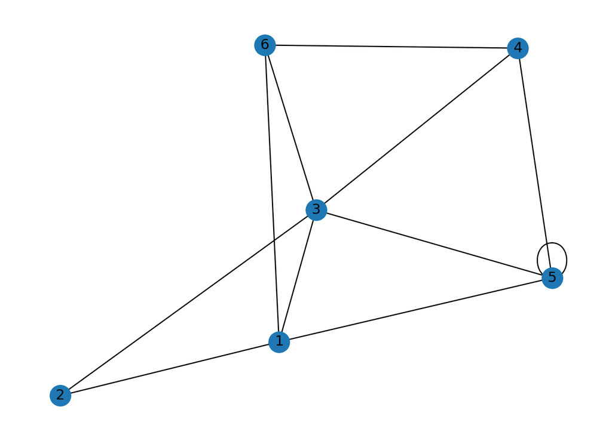

```python
G = nx.Graph() #creates an empty network graph

nodes = (1, 2, 3, 4, 5, 6) #our nodes, labeled 1,2,3,4,5,6.
edges = [(1, 2), (2, 3), (3, 1), (1,5), (3,5), (4, 5), (4, 6), (6, 1), (6, 3), (6,4), (4, 3), (5, 5), (3, 5)]
        #the connections between our nodes are stored in an array, containing pairs of numbers called tuples.
G.add_edges_from(edges) #the `add_edges_from()` command adds edges to the network
G.add_nodes_from(nodes) #the `add_nodes_from()` command adds nodes to the network

nx.draw(G, with_labels = True) #renders the graph in the notebook
        #the `with_labels = True` argument specifies that we want labels on the nodes.
```

Let’s create a directed graph using `nx.DiGraph()`.

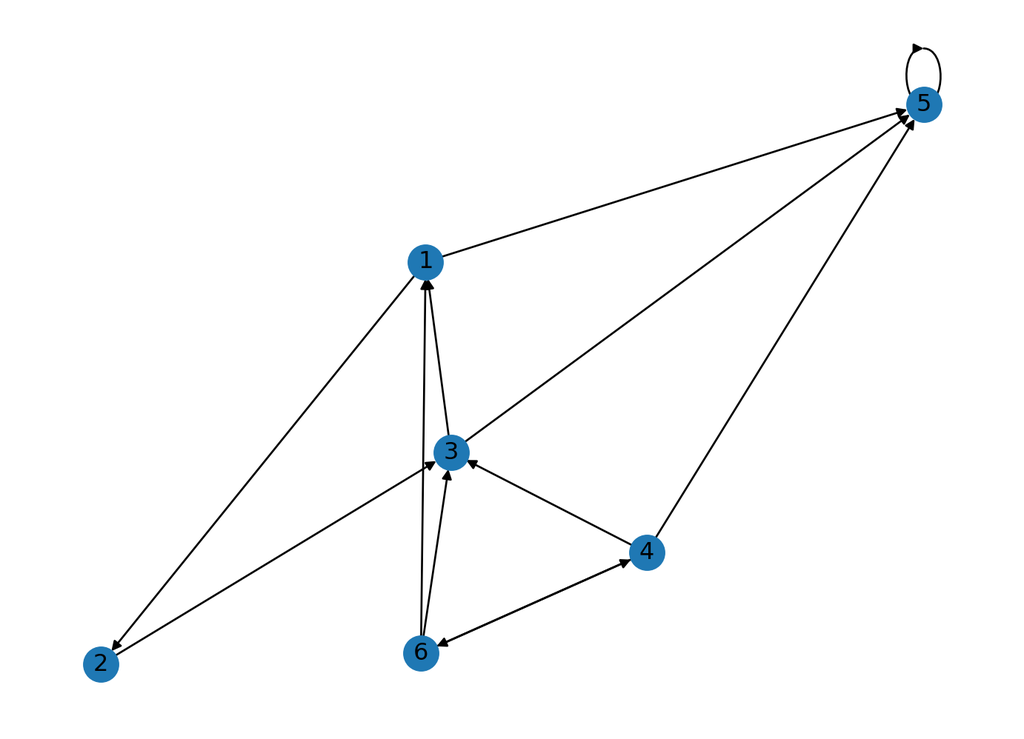

```python
G = nx.DiGraph() #creates an empty directed graph object
nodes = (1, 2, 3, 4, 5, 6) #our nodes
edges = [(1, 2), (2, 3), (3, 1), (1,5), (3,5), (4, 5), (4, 6), (6, 1), (6, 3), (6,4), (4, 3), (5, 5), (3, 5)] #our tuples stored in an array which represent our nodes
G.add_edges_from(edges) #connects edges to nodes
G.add_nodes_from(nodes) #connects edges to nodes

position = nx.spring_layout(G, seed=100)

#nx.draw plots our network
nx.draw(G, pos = position, with_labels = True) # `pos` argument assigns a position to each node
```

### 1.3 Creating Random Graphs

Instead of creating a graph with predetermined positions of nodes and edges we can also generate a random graph with a set amount of nodes and edges. Below you can change the amount of nodes and edges by changing `n` and `d` which correspond to the number of nodes and the degree (number of edges) that each node has. Creating a random graph could be more helpful for testing or when you want to try something and don’t wish to spend time plotting a real network and determining paths for all edges and nodes.

The command we will use is the `nx.random_regular_graph` command. Which generates a random regular graph. We’ll also set our node positions using a seed: this will ensure that each time the nodes are rendered they hold the same position on the graph. You can set the seed to any number.

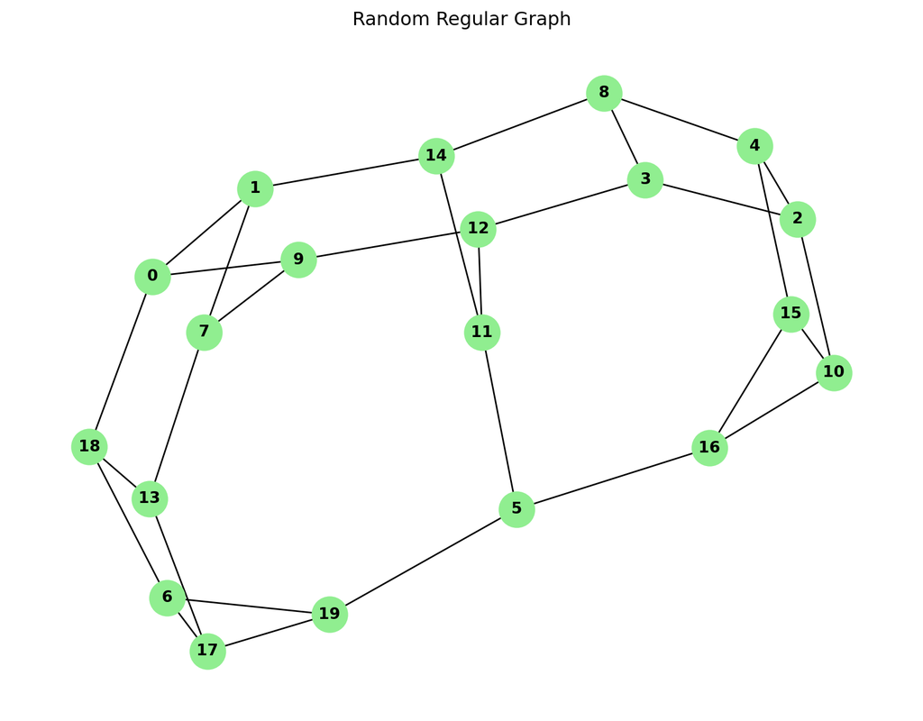

```
Number of nodes: 20
Number of edges: 30
Degree of each node: 3
```

```python
# Set a seed for reproducibility so that everytime the code runs we get the same random graph
random.seed(42)

# Parameters
n = 20  # number of nodes
d = 3   # degree of each node

# Generate the random regular graph
rr_graph = nx.random_regular_graph(d, n)

# Visualize the graph, you can change the size, color, font and node size.
plt.figure(figsize=(8, 6))
nx.draw(rr_graph, with_labels=True, node_color='lightgreen', node_size=500, font_size=10, font_weight='bold')
plt.title("Random Regular Graph")
plt.show()

# Print some basic information about the graph
print(f"Number of nodes: {rr_graph.number_of_nodes()}")
print(f"Number of edges: {rr_graph.number_of_edges()}")
print(f"Degree of each node: {d}")
```

## 2. Degrees, Density and Weights

### 2.1 Degrees

The **degree** of a node is the number of edges that are connected to a node.

We can see the degree of each node by running `dict(G.degree())`. This create a dictionary of key-value pairs for our network, where each key is the name of the node and the value is it’s respective degree.

```python
degrees = dict(G.degree())
```

If we want to see the degree of node $n$, we can do so by running `print(degrees[n])`. For instance:

```python
print(degrees[1])
```

```
4
```

Let’s color the nodes of our graph based on their degree. We’ll create a function called `get_node_colors` which takes in the degree dictionary of each node and returns a color. We’ll then create a for-loop that iterates over each nodes in the list of nodes, gets the color of each node using the `get_node_colors` function we defined earlier, and appends it to an empty list called `color_map`.

```python
degrees = dict(G.degree())
nodes = list(G.nodes())

def get_node_colors(degree):
    if degree in [1, 2]:
        return 'blue'
    elif degree in [3, 4]:
        return 'green'
    elif degree in [5, 6]:
        return 'yellow'
    else:
        return 'red'

color_map = [] #`color_map` is an empty list

for node in nodes:
  color = get_node_colors(degrees[node]) # get color of current node using node_colors according to degree of node
  color_map.append(color) # appends color of each node to color_map for each node in nodes

print(degrees)
print(nodes)
print(color_map)
```

```
{1: 4, 2: 2, 3: 5, 5: 5, 4: 4, 6: 4}
[1, 2, 3, 5, 4, 6]
['green', 'blue', 'yellow', 'yellow', 'green', 'green']
```

The $n$-th entry in `color_map` corresponds to the $n$-th node in `nodes`. For instance, `color_map[0]` returns the color of the first node (1).

```python
color_map[0]
```

```
'green'
```

We can now color the nodes of our graph, using the color map we defined above. The `node_color` argument takes in an array or list of colors that it uses to color each node.

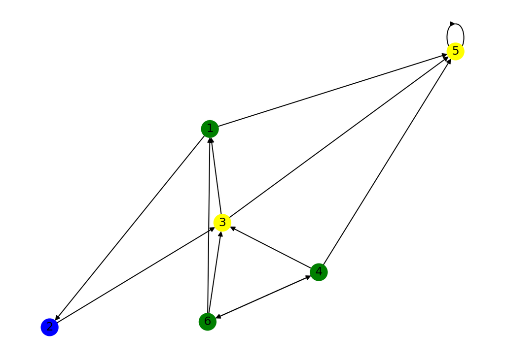

```python
G = nx.DiGraph() # creates an empty directed graph object
nodes = (1, 2, 3, 4, 5, 6)
edges = [(1, 2), (2, 3), (3, 1), (1,5), (3,5), (4, 5), (4, 6), (6, 1), (6, 3), (6,4), (4, 3), (5, 5), (3, 5)]
G.add_edges_from(edges)
G.add_nodes_from(nodes)

position = nx.spring_layout(G, seed=100)

nx.draw(G, pos = position, node_color=color_map, with_labels=True)
    # node_color argument colors the nodes based on a given list or array of colors,
    # with the first color corresponding to the first node, second to the second node, etc.
```

Let’s also add a legend to our graph, which gives information about the meaning of each color. We’ll do this using the `mpatches` subpackage we imported earlier.

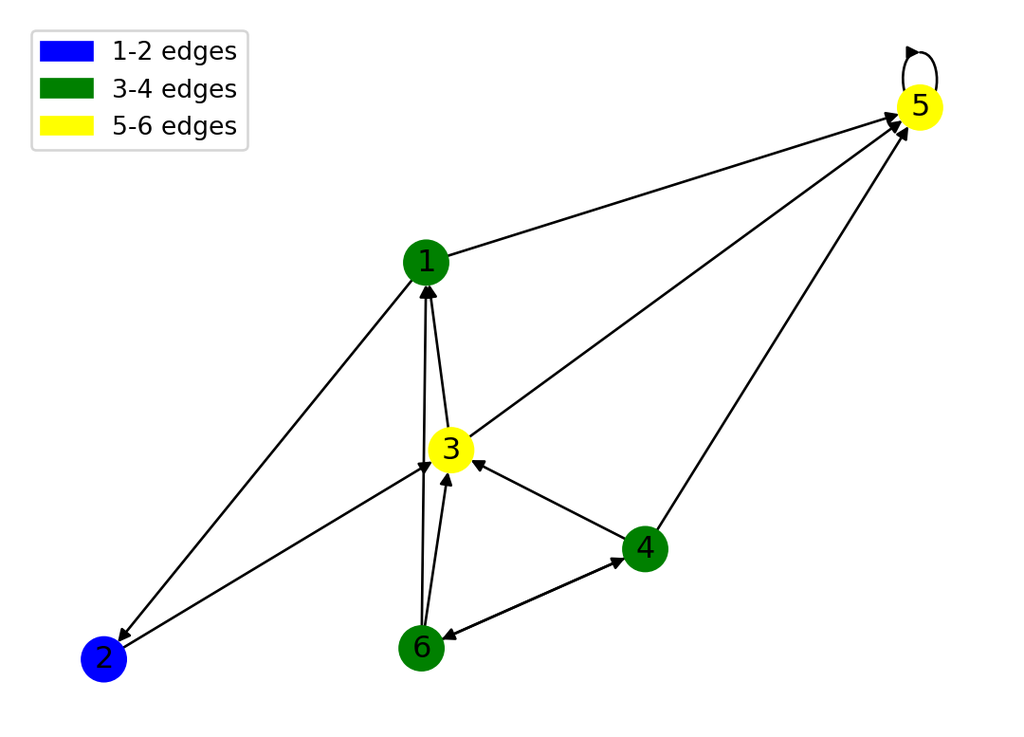

```python
blue_patch = mpatches.Patch(color='blue', label='1-2 edges')
green_patch = mpatches.Patch(color='green', label='3-4 edges')
yellow_patch = mpatches.Patch(color='yellow', label='5-6 edges')
plt.legend(handles=[blue_patch, green_patch, yellow_patch]) #adds legend to the plot

nx.draw(G, pos = position, node_color=color_map, with_labels=True)
```

### 2.2 Density

Density refers to the proportion of actual edges in a network compared to the total possible connections. It indicates how interconnected the nodes in a network are, with a higher density suggesting a more connected network. Density is defined from [0,1], meaning a network with a density of 0.95 is very interconncected. Note that self-loops (edges from and to the same node) are counted in the total number of edges but not in the maximum number of edges so graphs can have a density greater than 1.

We can calculate the density of our graph:

```python
nx.density(G)
```

```
0.4
```

### 2.3 Weights

Often times, you may end up working with *weighted* graphs: for instance, these weights could correspond to popularity of roads in road networks, or the size of pipes in a sewage network.

We’ll standardize our weights to be between 1 and 2 (as otherwise the results are messy). We’ll do this using a for-loop, like we did with the degrees.

```
[1.0, 1.8333333333333335, 1.4166666666666667, 1.8333333333333335, 1.6666666666666665, 1.0, 1.0, 1.4166666666666667, 2.0, 1.8333333333333335, 1.8333333333333335, 1.0, 1.0]
```

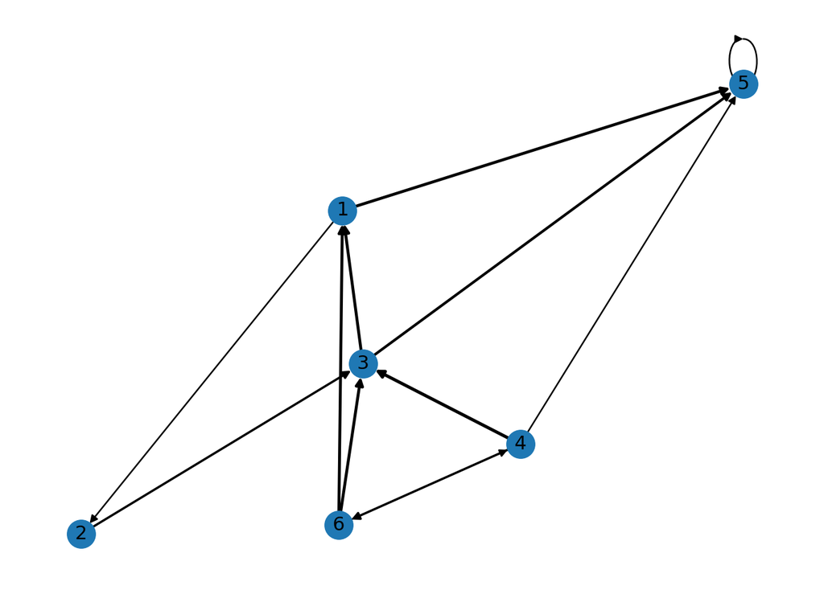

```python
G_weights = nx.DiGraph() #creating a new graph object called G_weights
nodes = [1, 2, 3, 4, 5, 6]
edges = [(1, 2), (2, 3), (3, 1), (1,5), (3,5), (4, 5), (4, 6), (6, 1), (6, 3), (6,4), (4, 3), (5, 5), (3, 5)]
weights = [100, 50, 75, 50, 60, 100, 100, 75, 40, 50, 50, 100, 100] #add list of weights
G_weights.add_edges_from(edges)
G_weights.add_nodes_from(nodes)

adjusted_weights = []
for weight in weights:
    adjusted_weight = 1+ (max(weights)-weight)/(max(weights)-min(weights)) #standardizes weights to be between 1 and 2
    adjusted_weights.append(adjusted_weight)

position = nx.spring_layout(G, seed=100)

print(adjusted_weights)
nx.draw(G_weights, pos = position, width = adjusted_weights, with_labels = True)
    # width argument take in a list or array of numbers corresponding to weights
```

This is great, but the results aren’t very clear. Let’s add a color gradient to the edges to represent different weights.

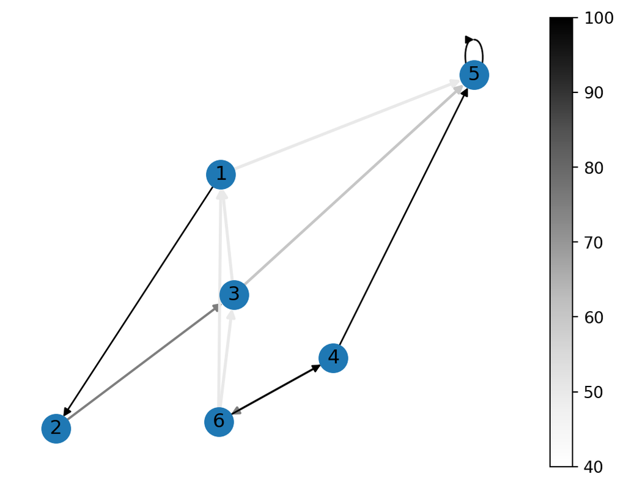

```python
norm = plt.Normalize(min(weights), max(weights), clip=False)
    #`plot.normalizes` normalizes the weights such that they are evenly distributed across the gradient spectrum
edge_colors = plt.cm.Greys(norm(weights))
    # norm(weights) normalizes the weights
    # plot.cm.greys() assigns the weights to color values
    # edge_colors is a multidimensional array of RGBA color values corresponding to each edge

fig, ax = plt.subplots() #explicitly specifying figure and axes in order to create a color bar

nx.draw(G_weights, pos=position, edge_color=edge_colors, width=adjusted_weights, with_labels=True, ax=ax)
    #ax = ax argument needed for color bar

# Adding color bar
sm = plt.cm.ScalarMappable(cmap="Greys", norm=norm) # creates a scalarmappable object which acts
                                                    # as a bridge between the numerical weight values and color map
plt.colorbar(sm, ax=ax) #plotting color bar
```

## 3. Adjacency matrices

An **Adjacency matrix** is a method of representing graphs in matrix form. In an adjacency matrix, the rows and columns correspond to the vertices (or nodes) of the graph. The entries of the matrix indicate whether pairs of vertices are adjacent or not in the graph. Normally, a value of 1 is assigned to entries where an edge is present, and 0 is assigned to entries where an edge is not. For a weighed graph, the weight of the edge is represented as a numerical value for entries where an edge is present.

We can convert our simple graph to an adjacency matrix:

```python
nx.to_pandas_adjacency(G)
```

|  | 1 | 2 | 3 | 5 | 4 | 6 |
| --- | --- | --- | --- | --- | --- | --- |
| 1 | 0.0 | 1.0 | 0.0 | 1.0 | 0.0 | 0.0 |
| 2 | 0.0 | 0.0 | 1.0 | 0.0 | 0.0 | 0.0 |
| 3 | 1.0 | 0.0 | 0.0 | 1.0 | 0.0 | 0.0 |
| 5 | 0.0 | 0.0 | 0.0 | 1.0 | 0.0 | 0.0 |
| 4 | 0.0 | 0.0 | 1.0 | 1.0 | 0.0 | 1.0 |
| 6 | 1.0 | 0.0 | 1.0 | 0.0 | 1.0 | 0.0 |

If we want to use our weighted graph, we can use the following code:

```python
# len(edges) returns the total number of entries in the list of edges.
# range(len(edges)): This generates a sequence of numbers from 0 to n-1 where n is len(edges),
    #so the for-loop will run n times with i taking each value in that range, one at a time.

for i in range(len(edges)):
    edge = edges[i] # retrieves the edge at position i in the list of edges
    weight = weights[i] # retrieves the weight at position i in the list of weights
    G_weights.add_edge(edge[0], edge[1], weight=weight) # adds an edge with a weight to the graph

nx.to_pandas_adjacency(G_weights, nodelist=nodes, weight='weight') #converts to pandas adjacency matrix with the weights in place
```

|  | 1 | 2 | 3 | 4 | 5 | 6 |
| --- | --- | --- | --- | --- | --- | --- |
| 1 | 0.0 | 100.0 | 0.0 | 0.0 | 50.0 | 0.0 |
| 2 | 0.0 | 0.0 | 50.0 | 0.0 | 0.0 | 0.0 |
| 3 | 75.0 | 0.0 | 0.0 | 0.0 | 100.0 | 0.0 |
| 4 | 0.0 | 0.0 | 50.0 | 0.0 | 100.0 | 100.0 |
| 5 | 0.0 | 0.0 | 0.0 | 0.0 | 100.0 | 0.0 |
| 6 | 75.0 | 0.0 | 40.0 | 50.0 | 0.0 | 0.0 |

We can visualize our matrix using the code below. Note that instead of using `nx.to_pandas_adjacency` we use `nx.to_numpy_array`: this allows us to store the matrix in the form of an array.

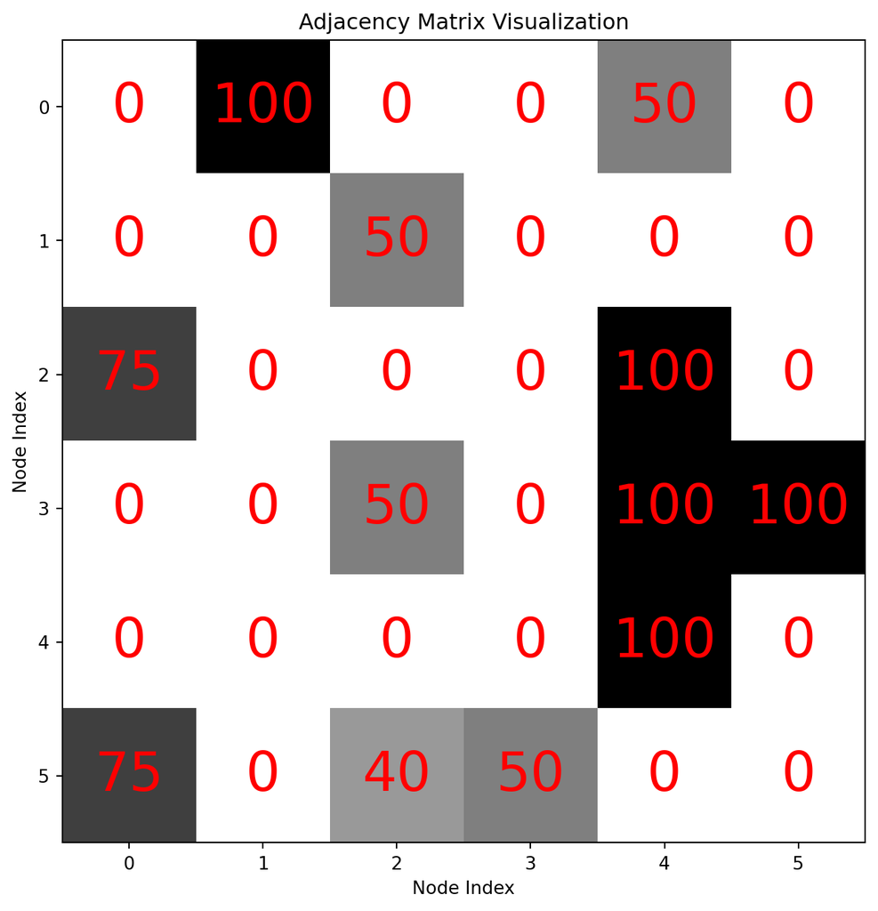

```python
adj_matrix = nx.to_numpy_array(G_weights, nodelist=nodes, weight='weight')


plt.figure(figsize=(8, 8)) #displays data as an image on a 2d raster; in our case, a numpy array

plt.imshow(adj_matrix, cmap='gray_r')

for i in range(adj_matrix.shape[0]): #loops through each row of the matrix
    for j in range(adj_matrix.shape[1]): #for each row, loops through each column of the matrix
        plt.text(j, i, int(adj_matrix[i, j]),
                 ha='center', va='center', color='red', size=30) #prints the value at that position in the matrix on the graph

plt.title('Adjacency Matrix Visualization')
plt.xlabel('Node Index')
plt.ylabel('Node Index')
```